# Practice

## HyperParameter tuning with different Regression Models

Hyperparameter tuning is the process of selecting the best set of hyperparameters to optimize a machine learning model’s performance. Unlike model parameters, which are learned from data, hyperparameters are set before training and can significantly impact the model's accuracy, complexity, and generalization ability. Effective tuning helps prevent overfitting, underfitting, and improves predictive performance. Regression Models used in this project :

- Linear Regression
- Polynomial Regression
- Support Vector Regression (SVR)
- K-Nearest Neighbout (KNN)
- Decision Tree
- Random Forest

```python
import pandas as pd
import numpy as np
import matplotlib.pyplot as plt

df = pd.read_csv("emp_sal.csv")
```

```python
df.head(6)
```

|  | Position | Level | Salary |
| --- | --- | --- | --- |
| 0 | Jr Software Engineer | 1 | 45000 |
| 1 | Sr Software Engineer | 2 | 50000 |
| 2 | Team Lead | 3 | 60000 |
| 3 | Manager | 4 | 80000 |
| 4 | Sr manager | 5 | 110000 |
| 5 | Region Manager | 6 | 150000 |

Simple Dataset with one independent variable i.e. Level and dependent varaible being salary.  
Objective is to `predict salary of someone with 5.5 years of experience` with this dataset. which  
`should be between 110K to 150K.`

```python
x = df.iloc[:,1].values.reshape(-1,1)
y = df.iloc[:,2].values.reshape(-1,1)
```

### Simple Linear Regression

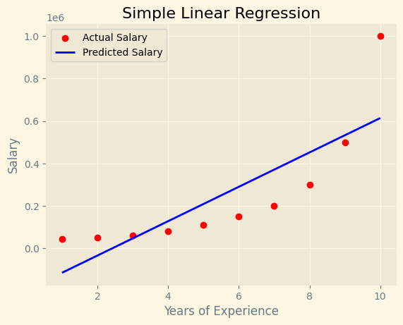

```python
from sklearn.linear_model import LinearRegression
l_reg= LinearRegression()
l_reg.fit(x,y)
plt.style.use('Solarize_Light2')
plt.scatter(x,y, color = "red", label = "Actual Salary")
plt.plot(x, l_reg.predict(x), color = "blue", label = "Predicted Salary")
plt.xlabel("Years of Experience")
plt.ylabel("Salary")
plt.title("Simple Linear Regression")
plt.legend()
plt.show()
```

```python
years = [[5.5]]
lreg_pre_salary = l_reg.predict(years)[0][0]
print(f"Salary of a person with {years[0][0]} years of experience predicted as per as SLR model is: {lreg_pre_salary}")
```

```
Salary of a person with 5.5 years of experience predicted as per as SLR model is: 249500.0
```

`Salary of a person with 5.5 years of experience predicted as per as SLR model is: 249500.0`  
`This is clearly wrong and as visible from the graph, the linear model has a high bias so not a good fit.`

Metrics of linear Reression

```python
from sklearn import metrics as met

l_reg_mse = met.mean_squared_error(y, l_reg.predict(x))
l_reg_rmse = met.root_mean_squared_error(y, l_reg.predict(x))
l_reg_mae = met.mean_absolute_error(y, l_reg.predict(x))
l_reg_r2score = met.r2_score(y, l_reg.predict(x))

print(f"Mean Squared Error : {l_reg_mse}")
print(f"Root Mean Squared Error : {l_reg_rmse}")
print(f"Mean Absolute Error : {l_reg_mae}")
print(f"r2_score : {l_reg_r2score}")
```

```
Mean Squared Error : 26695878787.878784
Root Mean Squared Error : 163388.73519272613
Mean Absolute Error : 128454.54545454546
r2_score : 0.6690412331929895
```

```python
df2 = pd.DataFrame(index = range(100), columns = ["model", "parameters", "predicted_Salary"])
```

### Polynomial Regression

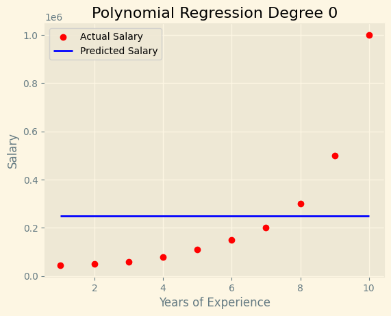

```
Mean Squared Error : 80662250000.0
Root Mean Squared Error : 284011.0033079705
Mean Absolute Error : 210300.0
r2_score : 0.0
Salary of a person with 5.5 years of experience predicted as per Polynomial Regression model is: 249500.0
```

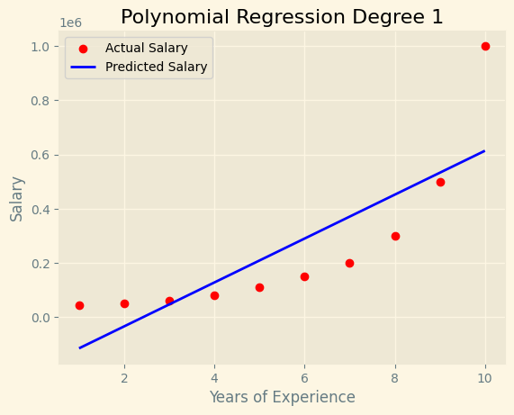

```
Mean Squared Error : 26695878787.878788
Root Mean Squared Error : 163388.73519272613
Mean Absolute Error : 128454.54545454544
r2_score : 0.6690412331929895
Salary of a person with 5.5 years of experience predicted as per Polynomial Regression model is: 249500.0
```

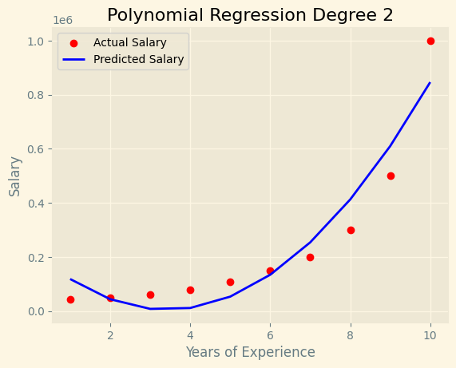

```
Mean Squared Error : 6758833333.333338
Root Mean Squared Error : 82212.12400451249
Mean Absolute Error : 70218.1818181819
r2_score : 0.9162082221443942
Salary of a person with 5.5 years of experience predicted as per Polynomial Regression model is: 89187.49999999988
```

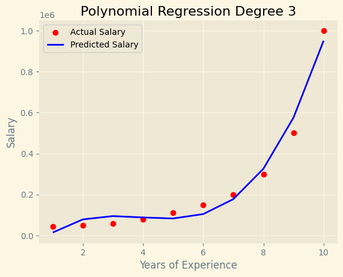

```
Mean Squared Error : 1515662004.6620114
Root Mean Squared Error : 38931.504012329286
Mean Absolute Error : 34790.20979020961
r2_score : 0.9812097727913366
Salary of a person with 5.5 years of experience predicted as per Polynomial Regression model is: 89187.50000000221
```

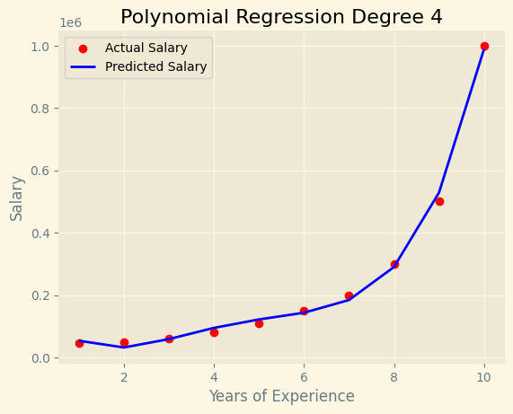

```
Mean Squared Error : 210343822.84381685
Root Mean Squared Error : 14503.234909626777
Mean Absolute Error : 12681.818181828514
r2_score : 0.9973922891706614
Salary of a person with 5.5 years of experience predicted as per Polynomial Regression model is: 132148.43750002387
```

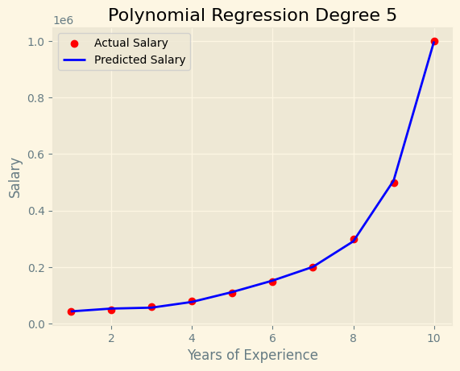

```
Mean Squared Error : 16382284.38228488
Root Mean Squared Error : 4047.5034752653246
Mean Absolute Error : 3360.83916091242
r2_score : 0.9997969027099755
Salary of a person with 5.5 years of experience predicted as per Polynomial Regression model is: 132148.43750059872
```

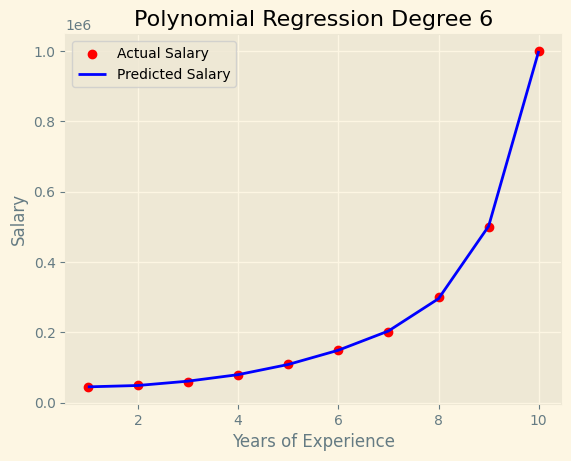

```
Mean Squared Error : 4075466.200466927
Root Mean Squared Error : 2018.7783931048318
Mean Absolute Error : 1476.4568763643576
r2_score : 0.9999494749253776
Salary of a person with 5.5 years of experience predicted as per Polynomial Regression model is: 127625.7324206162
```

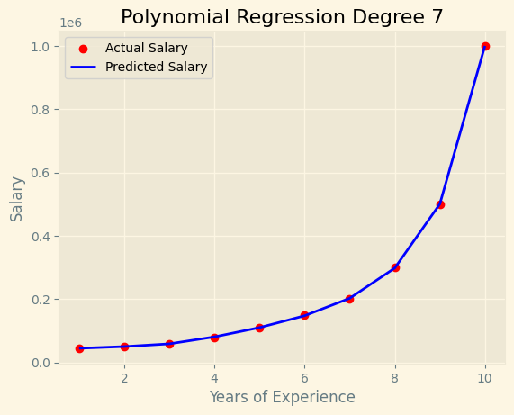

```
Mean Squared Error : 1854072.3981826133
Root Mean Squared Error : 1361.6432712655005
Mean Absolute Error : 1025.3805305935443
r2_score : 0.9999770143729169
Salary of a person with 5.5 years of experience predicted as per Polynomial Regression model is: 127625.73245149036
```

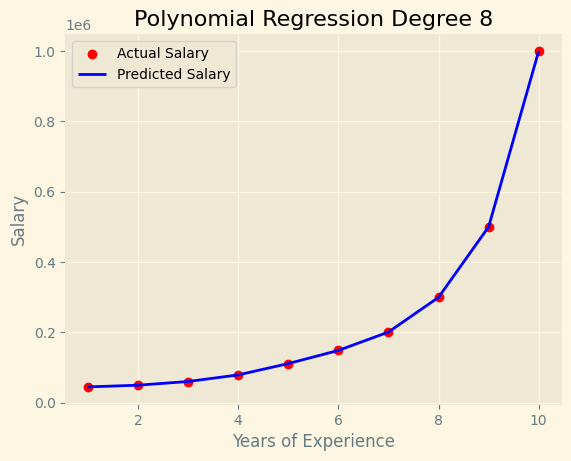

```
Mean Squared Error : 524526.9436397381
Root Mean Squared Error : 724.242323839016
Mean Absolute Error : 531.7980682222988
r2_score : 0.9999934972438329
Salary of a person with 5.5 years of experience predicted as per Polynomial Regression model is: 129396.13304185169
```

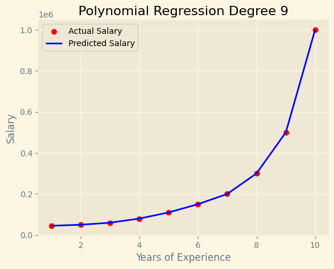

```
Mean Squared Error : 0.0014117194172830081
Root Mean Squared Error : 0.03757285479282893
Mean Absolute Error : 0.026190568692982197
r2_score : 0.9999999999999825
Salary of a person with 5.5 years of experience predicted as per Polynomial Regression model is: 129396.14697174076
```

```python
for i in range(10):
    from sklearn.preprocessing import PolynomialFeatures
    poly = PolynomialFeatures(degree=i)
    x_poly = poly.fit_transform(x)
    poly_reg = LinearRegression()
    poly_reg.fit(x_poly, y)

    plt.scatter(x,y, color = "red", label = "Actual Salary")
    plt.plot(x, poly_reg.predict(x_poly), color = "blue", label = "Predicted Salary")
    plt.xlabel("Years of Experience")
    plt.ylabel("Salary")
    plt.title(f"Polynomial Regression Degree {i}")
    plt.legend()
    plt.show()

    poly_reg_mse = met.mean_squared_error(y, poly_reg.predict(x_poly))
    poly_reg_rmse = met.root_mean_squared_error(y, poly_reg.predict(x_poly))
    poly_reg_mae = met.mean_absolute_error(y, poly_reg.predict(x_poly))
    poly_reg_r2score = met.r2_score(y, poly_reg.predict(x_poly))

    print(f"Mean Squared Error : {poly_reg_mse}")
    print(f"Root Mean Squared Error : {poly_reg_rmse}")
    print(f"Mean Absolute Error : {poly_reg_mae}")
    print(f"r2_score : {poly_reg_r2score}")
    polyreg_pre_salary = poly_reg.predict(poly.fit_transform(years))[0][0]
    print(f"Salary of a person with {years[0][0]} years of experience predicted as per Polynomial Regression model is: {polyreg_pre_salary}")
    df2.iloc[i] = ["Polynomial Regression", f"degree : {i}", polyreg_pre_salary]
```

- As the degree of the model increases, the graph fits better to the data (this can lead to overfitting but that is not the scope of this project).
- Degree 1 is just Simple Linear Regression model.
- `Predicted Salary from this model comes out to be 129K`

### Support Vector Regression

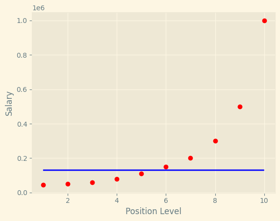

```
Salary of a person with 5.5 years of experience predicted as per SVR model is: 130000.0
```

```python
from sklearn import svm
svr_reg = svm.SVR()

svr_reg.fit(x,y.flatten())

plt.scatter(x,y, color = "red")
plt.plot(x, svr_reg.predict(x), color = "blue")
plt.xlabel("Position Level")
plt.ylabel("Salary")
plt.show()

svr_pre_salary = svr_reg.predict(years)[0]
print(f"Salary of a person with {years[0][0]} years of experience predicted as per SVR model is: {svr_pre_salary}")
df2.iloc[10] = ["Support Vector Regression", "default", svr_pre_salary]
```

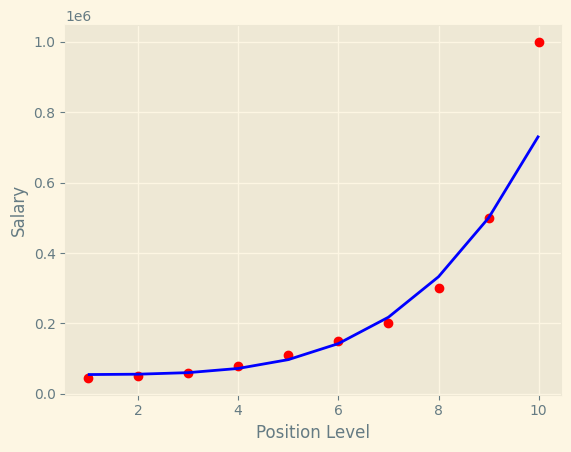

```
Salary of a person with 5.5 years of experience predicted as per SVR model is: 116633.57528238308
```

```python
from sklearn import svm
svr_reg = svm.SVR(kernel = "poly", degree =4, gamma = "auto", C = 2.0)

svr_reg.fit(x,y.flatten())

plt.scatter(x,y, color = "red")
plt.plot(x, svr_reg.predict(x), color = "blue")
plt.xlabel("Position Level")
plt.ylabel("Salary")
plt.show()

svr_pre_salary = svr_reg.predict(years)[0]
print(f"Salary of a person with {years[0][0]} years of experience predicted as per SVR model is: {svr_pre_salary}")
df2.iloc[11] = ['Support Vector Regression', 'kernel = "poly", degree =4, gamma = "auto", C = 2.0)', svr_pre_salary]
```

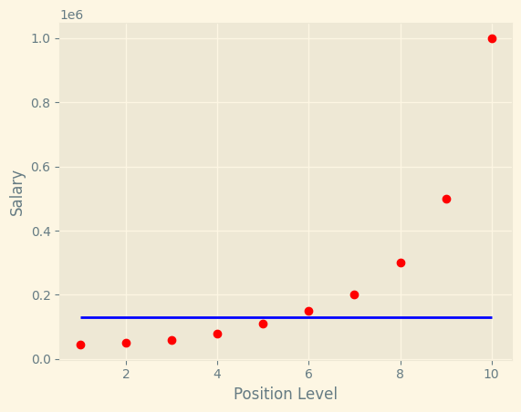

```
Salary of a person with 5.5 years of experience predicted as per SVR model is: 130000.0
```

```python
from sklearn import svm
svr_reg = svm.SVR(kernel = "sigmoid", degree =5, gamma = "auto", C = 4.0, coef0=9)

svr_reg.fit(x,y.flatten())

plt.scatter(x,y, color = "red")
plt.plot(x, svr_reg.predict(x), color = "blue")
plt.xlabel("Position Level")
plt.ylabel("Salary")
plt.show()

svr_pre_salary = svr_reg.predict(years)[0]
print(f"Salary of a person with {years[0][0]} years of experience predicted as per SVR model is: {svr_pre_salary}")
df2.iloc[12] = ['Support Vector Regression', 'kernel = "poly", degree =4, gamma = "auto", C = 2.0)', svr_pre_salary]
```

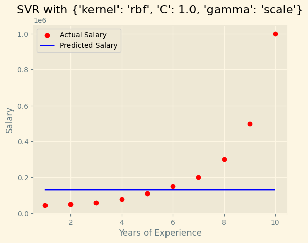

```
Predicted salary with {'kernel': 'rbf', 'C': 1.0, 'gamma': 'scale'}: 130000.0
```

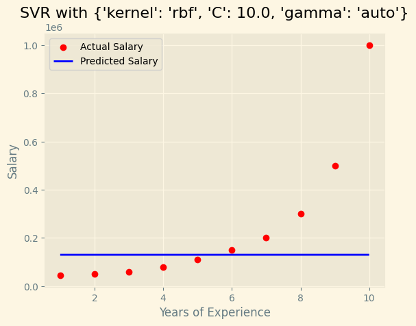

```
Predicted salary with {'kernel': 'rbf', 'C': 10.0, 'gamma': 'auto'}: 130000.0
```

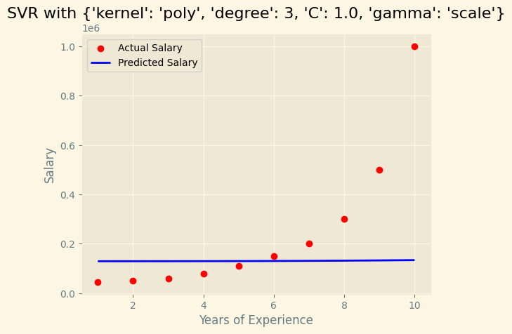

```
Predicted salary with {'kernel': 'poly', 'degree': 3, 'C': 1.0, 'gamma': 'scale'}: 129981.08355392543
```

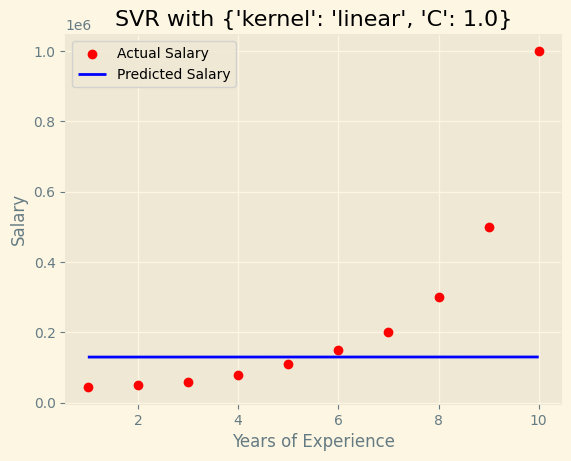

```
Predicted salary with {'kernel': 'linear', 'C': 1.0}: 130000.0
```

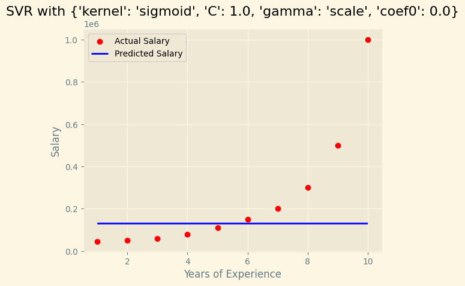

```
Predicted salary with {'kernel': 'sigmoid', 'C': 1.0, 'gamma': 'scale', 'coef0': 0.0}: 129999.99188055407
```

```python
svr_combinations = [
    {'kernel': 'rbf', 'C': 1.0, 'gamma': 'scale'},
    {'kernel': 'rbf', 'C': 10.0, 'gamma': 'auto'},
    {'kernel': 'poly', 'degree': 3, 'C': 1.0, 'gamma': 'scale'},
    {'kernel': 'linear', 'C': 1.0},
    {'kernel': 'sigmoid', 'C': 1.0, 'gamma': 'scale', 'coef0': 0.0}
]

for i, params in enumerate(svr_combinations):
    svr_reg = svm.SVR(**params)
    svr_reg.fit(x, y.flatten())

    plt.scatter(x, y, color="red", label="Actual Salary")
    plt.plot(x, svr_reg.predict(x), color="blue", label="Predicted Salary")
    plt.xlabel("Years of Experience")
    plt.ylabel("Salary")
    plt.title(f"SVR with {params}")
    plt.legend()
    plt.show()

    svr_pre_salary = svr_reg.predict(years)[0]
    print(f"Predicted salary with {params}: {svr_pre_salary}")
    df2.iloc[13+i] = ["Support Vector Regression", str(params), svr_pre_salary]
```

### K-Nearest Neighbour Regressor

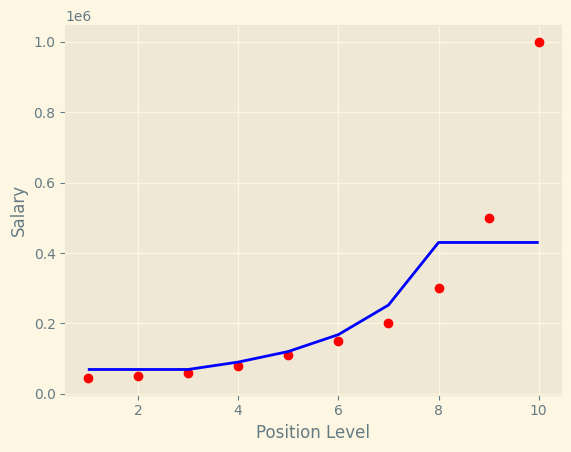

```
Predicted salary with KNN Regressor: 120000.0
```

```python
from sklearn.neighbors import KNeighborsRegressor
knn_reg = KNeighborsRegressor()

knn_reg.fit(x,y)

plt.scatter(x,y,color = "red")
plt.plot(x, knn_reg.predict(x), color = "Blue")
plt.xlabel("Position Level")
plt.ylabel("Salary")
plt.show()

knn_pre_salary = knn_reg.predict(years)[0][0]
print(f"Predicted salary with KNN Regressor: {knn_pre_salary}")
df2.iloc[18] = ["KNN Regression", "default", knn_pre_salary]
```

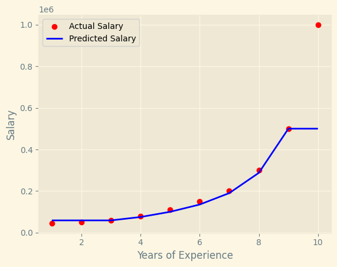

```
Predicted salary with {'n_neighbors': 4, 'weights': 'uniform', 'algorithm': 'ball_tree', 'leaf_size': 40, 'p': 3, 'metric': 'euclidean'}: 135000.0
```

```
Predicted salary with {'n_neighbors': 3, 'weights': 'distance', 'algorithm': 'auto', 'leaf_size': 30, 'p': 2, 'metric': 'minkowski'}: 122857.14285714286
```

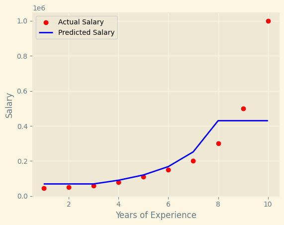

```
Predicted salary with {'n_neighbors': 5, 'weights': 'uniform', 'algorithm': 'kd_tree', 'leaf_size': 20, 'p': 1, 'metric': 'manhattan'}: 120000.0
```

```
Predicted salary with {'n_neighbors': 7, 'weights': 'distance', 'algorithm': 'ball_tree', 'leaf_size': 50, 'p': 3, 'metric': 'euclidean'}: 134747.77448071216
```

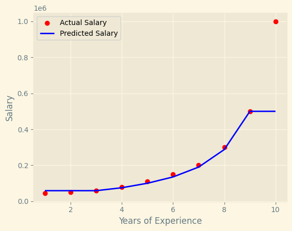

```
Predicted salary with {'n_neighbors': 4, 'weights': 'uniform', 'algorithm': 'brute', 'leaf_size': 10, 'p': 2, 'metric': 'minkowski'}: 135000.0
```

```
Predicted salary with {'n_neighbors': 6, 'weights': 'distance', 'algorithm': 'auto', 'leaf_size': 25, 'p': 1, 'metric': 'manhattan'}: 138695.65217391303
```

```python
knn_combinations = [{"n_neighbors":4, "weights":"uniform","algorithm":"ball_tree","leaf_size":40, "p":3,"metric":"euclidean"},
                    {"n_neighbors": 3, "weights": "distance", "algorithm": "auto", "leaf_size": 30, "p": 2, "metric": "minkowski"},
                    {"n_neighbors": 5, "weights": "uniform", "algorithm": "kd_tree", "leaf_size": 20, "p": 1, "metric": "manhattan"},
                    {"n_neighbors": 7, "weights": "distance", "algorithm": "ball_tree", "leaf_size": 50, "p": 3, "metric": "euclidean"},
                    {"n_neighbors": 4, "weights": "uniform", "algorithm": "brute", "leaf_size": 10, "p": 2, "metric": "minkowski"},
                    {"n_neighbors": 6, "weights": "distance", "algorithm": "auto", "leaf_size": 25, "p": 1, "metric": "manhattan"}]


for i, params in enumerate(knn_combinations):
    knn_reg = KNeighborsRegressor(**params)
    knn_reg.fit(x,y)

    plt.scatter(x, y, color="red", label="Actual Salary")
    plt.plot(x, knn_reg.predict(x), color="blue", label="Predicted Salary")
    plt.xlabel("Years of Experience")
    plt.ylabel("Salary")
    # plt.title(f"KNN with {params}")
    plt.legend()
    plt.show()
    knn_pre_salary = knn_reg.predict(years)[0]
    print(f"Predicted salary with {params}: {knn_pre_salary[0]}")
    df2.iloc[18+i] = ["KNN Regression", str(params), knn_pre_salary[0]]
```

### Decision Tree Regressor

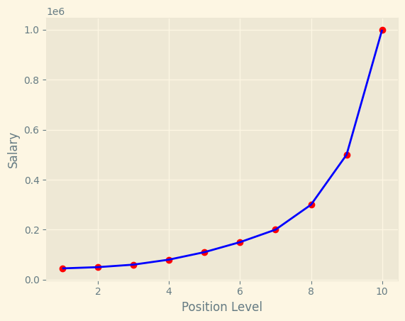

```
Predicted salary : 110000.0
```

```python
from sklearn.tree import DecisionTreeRegressor
dt_reg = DecisionTreeRegressor()
dt_reg.fit(x,y)

plt.scatter(x,y,color = "red")
plt.plot(x, dt_reg.predict(x), color = "Blue")
plt.xlabel("Position Level")
plt.ylabel("Salary")
plt.show()

dt_pre_salary = dt_reg.predict(years)[0]
print(f"Predicted salary : {dt_pre_salary}")
df2.iloc[23] = ["DT Regression", str(params), dt_pre_salary]
```

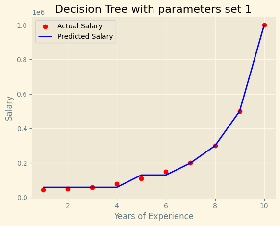

```
Predicted salary with {'max_depth': 3, 'min_samples_split': 2, 'min_samples_leaf': 1, 'random_state': 42}: 130000.0
```

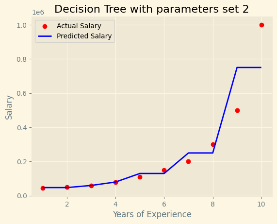

```
Predicted salary with {'max_depth': 5, 'min_samples_split': 3, 'criterion': 'friedman_mse', 'random_state': 42}: 130000.0
```

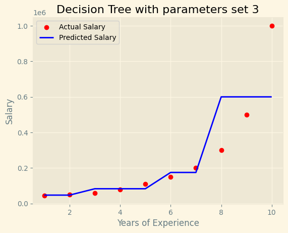

```
Predicted salary with {'max_depth': None, 'min_samples_split': 4, 'min_samples_leaf': 2, 'splitter': 'random', 'random_state': 42}: 83333.33333333333
```

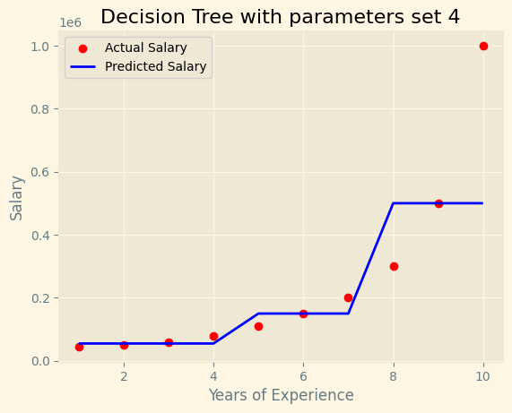

```
Predicted salary with {'max_depth': 4, 'criterion': 'absolute_error', 'min_samples_leaf': 3, 'random_state': 42}: 150000.0
```

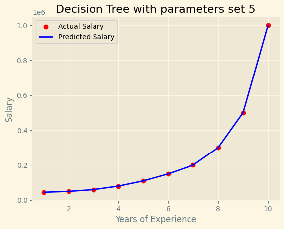

```
Predicted salary with {'max_depth': 6, 'splitter': 'best', 'min_weight_fraction_leaf': 0.1, 'random_state': 42}: 110000.0
```

```python
dt_combinations = [
    {'max_depth': 3, 'min_samples_split': 2, 'min_samples_leaf': 1, 'random_state': 42},
    {'max_depth': 5, 'min_samples_split': 3, 'criterion': 'friedman_mse', 'random_state': 42},
    {'max_depth': None, 'min_samples_split': 4, 'min_samples_leaf': 2, 'splitter': 'random', 'random_state': 42},
    {'max_depth': 4, 'criterion': 'absolute_error', 'min_samples_leaf': 3, 'random_state': 42},
    {'max_depth': 6, 'splitter': 'best', 'min_weight_fraction_leaf': 0.1, 'random_state': 42}
]

for i, params in enumerate(dt_combinations):
    dt_reg = DecisionTreeRegressor(**params)
    dt_reg.fit(x, y)

    plt.scatter(x, y, color="red", label="Actual Salary")
    plt.plot(x, dt_reg.predict(x), color="blue", label="Predicted Salary")
    plt.xlabel("Years of Experience")
    plt.ylabel("Salary")
    plt.title(f"Decision Tree with parameters set {i+1}")
    plt.legend()
    plt.show()

    dt_pre_salary = dt_reg.predict(years)[0]
    print(f"Predicted salary with {params}: {dt_pre_salary}")
    df2.iloc[24+i] = ["Decision Tree Regression", str(params), dt_pre_salary]
```